# Introduction to Sampling

February 9, 2021

## Sampling Concepts

- A **population** is a collection of individuals or observations we are interested in.
  - A **population parameter** is a numerical summary quantity about the population that is unknown, but you wish you knew.
- **Sampling** is the act of collecting a sample from the population when we don’t have the means to perform a census.
  - A **point estimate** is a summary statistic computed from a sample that estimates an unknown population parameter.

## Population Parameter

To investigate the relationship between course evaluation score and the professor’s age, we would carry out a simple linear regression.

- What would be the population parameter we are interested in? Do we know its value?
- What would be our point estimate? What is its purpose?

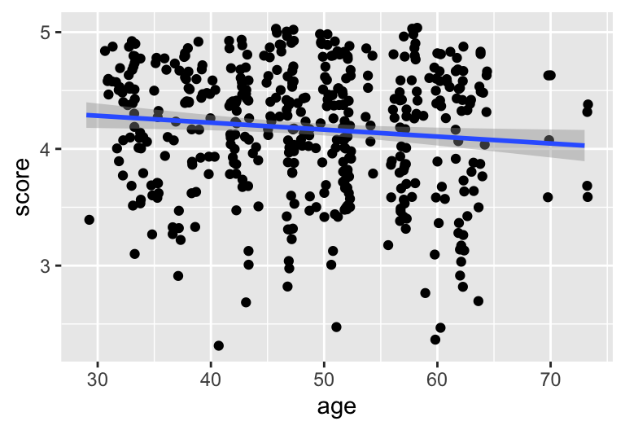

## Sampling Procedures

- A **census** is an exhaustive enumeration or counting of all individuals.
- A **representative sample** is a sample that looks roughly like the population.
- A **random sample** is a sample where every observation has the same probability of selection.
- A **biased sample** is a sample where certain individuals or observations in a population have a higher chance of being included than others.
- **Generalizability** is when the results from a sample can be *inferred* to the population.